# Getting data from the API “qualité des cours d’eau”

Philippe Amiotte Suchet, David Dorchies

This vignette describes how to use functions of the [R package *hubeau*](https://cran.r-project.org/package=hubeau) to query the French Naïades database through the [API “qualité des cours d’eau”](https://hubeau.eaufrance.fr/page/api-qualite-cours-deau).

The [Naïades database](https://naiades.eaufrance.fr/) gathers hydrobiology, hydrogeomophomogy and physico-chemical information for French river and lake water. The information is associated with a water quality station (location), a date (the day of the sampling or of the observation) and a material (water, suspended matter, sediment, river bed, fish, etc.). **The API “qualité des cours d’eau” focuses only on water physico-chemical properties.**

This example shows how to get physico-chemical information (here nitrates concentration) from the Naïades database on water monitoring sites belonging to an administrative entity (here the Cote d’Or department).

```r
library(hubeau)
library(dplyr)
library(lubridate)
library(ggplot2)
library(Hmisc)
```

# Get started

## How it works

The *hubeau* package provides functions to query the databases of the French water information system using the Hub’eau API.

The functions are named as follows: `hubeau::get_[API]_[endpoint](argument)` where:

- [API] is the name of the API (one API = one database)
- [endpoint] is the type of information which is queried in the database; the query is defined by a list of arguments.

For example the function `get_qualite_rivieres_station()` uses the API “qualité des cours d’eau” to get the water quality stations corresponding to requirements described in the `station()` function.

See the [readme in the R package *hubeau*](https://github.com/inrae/hubeau#api-hydrom%C3%A9trie).

## Listing the APIs searchable with the *hubeau* R package

The *hubeau* R package allows to query 11 databases which can be listed as follow:

```r
list_apis()
```

```
#>  [1] "prelevements"         "indicateurs_services" "hydrometrie"
#>  [4] "niveaux_nappes"       "poisson"              "ecoulement"
#>  [7] "hydrobio"             "temperature"          "qualite_eau_potable"
#> [10] "qualite_nappes"       "qualite_rivieres"
```

The name of the API which will be used below is `"qualite_rivieres"` using the [“qualité des cours d’eau” Hub’eau API](https://hubeau.eaufrance.fr/page/api-qualite-cours-deau) allowing to query the [Naïades database](https://naiades.eaufrance.fr/bienvenue-naiades).

## Available endpoints for the “qualite_rivieres” API

The function `list_endpoints(api = "name of the api given by <list_apis>")` of the *hubeau* R package lists the available endpoints. For the `qualite_rivieres` API it gives:

```r
list_endpoints(api = "qualite_rivieres")
```

```
#> [1] "analyse_pc"                    "condition_environnementale_pc"
#> [3] "operation_pc"                  "station_pc"
```

These 4 endpoints are described in the [Hub’eau web page of the API (see “opération” section)](https://hubeau.eaufrance.fr/page/api-qualite-cours-deau).

- [**station_pc**] lists the water stations with physico-chemical analysis;
- [**operation_pc**] lists the sampling operation occuring on each water station;
- [**condition_environnementale_pc**] lists the environmental conditions observed during water sampling (air temperature, presence of mosses, alguae, etc.);
- [**analyse_pc**] gives the results of the physico-chemical analysis made on water samples of a selected water station.

Each endpoint is defined by a list of arguments to query the database.

## List of arguments by endpoint

The function `list_params(api = "name of the api", endpoint = "name of the endpoint")` gives the arguments which can be used in the query. These arguments correspond to the parameters of the Hub’eau API and are described in the [Hub’eau web page of the API](https://hubeau.eaufrance.fr/page/api-qualite-cours-deau).

For example, the following instruction lists the available arguments for the endpoint “condition_environnementale_pc”:

```r
list_params(api = "qualite_rivieres", endpoint = "condition_environnementale_pc")
```

```
#>  [1] "bbox"                   "code_banque_reference"  "code_commune"
#>  [4] "code_cours_eau"         "code_departement"       "code_eu_masse_eau"
#>  [7] "code_groupe_parametres" "code_masse_eau"         "code_operation_cep"
#> [10] "code_parametre"         "code_point_eau_surface" "code_prelevement"
#> [13] "code_qualification"     "code_region"            "code_station"
#> [16] "code_statut"            "code_unite"             "commentaire"
#> [19] "date_debut_maj"         "date_debut_prelevement" "date_fin_maj"
#> [22] "date_fin_prelevement"   "distance"               "distance"
#> [25] "fields"                 "format"                 "latitude"
#> [28] "latitude"               "libelle_commune"        "libelle_departement"
#> [31] "libelle_masse_eau"      "libelle_parametre"      "libelle_qualification"
#> [34] "libelle_region"         "libelle_resultat"       "libelle_station"
#> [37] "longitude"              "longitude"              "mnemo_remarque"
#> [40] "mnemo_statut"           "nom_cours_eau"          "nom_groupe_parametres"
#> [43] "page"                   "resultat"               "size"
#> [46] "sort"
```

# Extracting physico-chemical data

This example shows how to extract the nitrates concentration values in river water samples for stations located in the Cote d’Or department from 2000 to 2022.

## Availability of stations in the Côte d’Or department

The function `get_qualite_rivieres_station(…)` will be used to list the available stations. Arguments for the function can be listed as follow:

```r
list_params(api = "qualite_rivieres", endpoint = "station_pc")
```

```
#>  [1] "bbox"                   "code_banque_reference"  "code_bassin_dce"
#>  [4] "code_commune"           "code_cours_eau"         "code_departement"
#>  [7] "code_eu_masse_eau"      "code_fraction"          "code_groupe_parametres"
#> [10] "code_masse_eau"         "code_parametre"         "code_qualification"
#> [13] "code_region"            "code_reseau"            "code_sous_bassin"
#> [16] "code_station"           "code_statut"            "code_support"
#> [19] "date_debut_maj"         "date_debut_prelevement" "date_fin_maj"
#> [22] "date_fin_prelevement"   "distance"               "distance"
#> [25] "exact_count"            "fields"                 "format"
#> [28] "latitude"               "latitude"               "libelle_commune"
#> [31] "libelle_departement"    "libelle_fraction"       "libelle_masse_eau"
#> [34] "libelle_parametre"      "libelle_qualification"  "libelle_region"
#> [37] "libelle_reseau"         "libelle_station"        "libelle_support"
#> [40] "longitude"              "longitude"              "mnemo_statut"
#> [43] "nom_bassin_dce"         "nom_cours_eau"          "nom_groupe_parametres"
#> [46] "nom_sous_bassin"        "page"                   "size"
#> [49] "sort"                   "type_entite_hydro"
```

The argument “code_departement” will be used with the value “21” which is the French administrative code for Côte d’Or.

```r
station_21 <- get_qualite_rivieres_station(code_departement = "21")
```

```r
station_21
```

```
#> # A tibble: 468 × 48
#>    code_station libelle_station     uri_station durete coordonnee_x coordonnee_y
#>    <chr>        <chr>               <chr>       <lgl>         <dbl>        <dbl>
#>  1 03000029     LE RUISSEAU DU FEU… https://id… NA          829934      6715298
#>  2 03000033     La Seine à Courceau https://id… NA          827760      6716247
#>  3 03000070     Ruisseau de Jugny   https://id… NA          829586      6718953
#>  4 03000100     LA SEINE A BAIGNEU… https://id… NA          826286      6724377
#>  5 03000180     LE RU DE COSNE A Q… https://id… NA          824754      6731499
#>  6 03000311     La coquille à Etal… https://id… NA          831785      6728503
#>  7 03000344     LA COQUILLE A AIGN… https://id… NA          830428      6730843
#>  8 03000346     La coquille à l'av… https://id… NA          829398      6731552
#>  9 03000440     LE REVINSON A DUES… https://id… NA          827650.     6730547.
#> 10 03000450     LE REVINSON A QUEM… https://id… NA          825751      6731858
#> # ℹ 458 more rows
#> # ℹ 42 more variables: code_projection <chr>, libelle_projection <chr>,
#> #   longitude <dbl>, latitude <dbl>, code_commune <chr>, libelle_commune <chr>,
#> #   code_departement <chr>, libelle_departement <chr>, code_region <chr>,
#> #   libelle_region <chr>, code_cours_eau <chr>, nom_cours_eau <chr>,
#> #   uri_cours_eau <chr>, code_masse_deau <chr>, code_eu_masse_deau <chr>,
#> #   nom_masse_deau <chr>, uri_masse_deau <chr>, code_eu_sous_bassin <chr>, …
```

## Retrieving nitrate concentration in river water of the Côte d’or department

The function `get_qualite_rivieres_analyse(…)` is used to get the physico-chemical analysis for selected stations. Arguments for the function can be listed as follow:

```r
list_params(api = "qualite_rivieres", endpoint = "analyse_pc")
```

```
#>  [1] "bbox"                   "code_analyse"           "code_banque_reference"
#>  [4] "code_bassin_dce"        "code_commune"           "code_cours_eau"
#>  [7] "code_departement"       "code_eu_masse_eau"      "code_fraction"
#> [10] "code_groupe_parametres" "code_masse_eau"         "code_operation"
#> [13] "code_parametre"         "code_point_eau_surface" "code_prelevement"
#> [16] "code_qualification"     "code_region"            "code_reseau"
#> [19] "code_sous_bassin"       "code_station"           "code_statut"
#> [22] "code_support"           "date_debut_maj"         "date_debut_prelevement"
#> [25] "date_fin_maj"           "date_fin_prelevement"   "distance"
#> [28] "distance"               "fields"                 "format"
#> [31] "latitude"               "latitude"               "libelle_commune"
#> [34] "libelle_departement"    "libelle_fraction"       "libelle_masse_eau"
#> [37] "libelle_parametre"      "libelle_qualification"  "libelle_region"
#> [40] "libelle_reseau"         "libelle_station"        "libelle_support"
#> [43] "longitude"              "longitude"              "mnemo_statut"
#> [46] "nom_bassin_dce"         "nom_cours_eau"          "nom_groupe_parametres"
#> [49] "nom_sous_bassin"        "page"                   "size"
#> [52] "sort"                   "type_entite_hydro"
```

These arguments are described in the [Hub’eau API web page](https://hubeau.eaufrance.fr/page/api-qualite-cours-deau#/physicochimie/analyse_pc).

The arguments in this example are:

- `code_departement`: French administrative code for department (“21” for Côte d’Or)
- `code_param`: Code of the physico-chemical parameter; if more than one parameter, codes must be separated by a commas; the maximum number of codes is 200. The code of a given parameter that can be found in the [French water reference system “Sandre”](https://www.sandre.eaufrance.fr/Rechercher-une-donnee-d-un-jeu). For nitrates the code is “1340”
- `date_debut_prelevement` et `date_fin_prelevement`: beginning and end dates of samples (“*yyyy-mm-dd*” format).

The query can be written as follows:

```r
nitrates_21_raw <- get_qualite_rivieres_analyse(code_departement = "21",
                                            date_debut_prelevement = "2000-01-01",
                                            date_fin_prelevement = "2000-12-31",
                                            code_parametre = "1340")
```

```r
dim(nitrates_21_raw)
```

```
#> [1] 221 125
```

```r
nitrates_21_raw
```

```
#> # A tibble: 221 × 125
#>    code_station libelle_station         uri_station code_support libelle_support
#>    <chr>        <chr>                   <chr>       <chr>        <chr>
#>  1 06011000     "SAONE A AUXONNE 1"     https://id… 3            Eau
#>  2 06017050     "SAONE A CHARREY-SUR-S… https://id… 3            Eau
#>  3 03002100     "LA SEINE A CHARREY-SU… https://id… 0            Support inconnu
#>  4 06016500     "OUCHE A ECHENON "      https://id… 3            Eau
#>  5 06016000     "OUCHE A CRIMOLOIS 1"   https://id… 3            Eau
#>  6 06013800     "TILLE A CHAMPDOTRE 1"  https://id… 3            Eau
#>  7 03041000     "LA BRENNE A SAINT-REM… https://id… 3            Eau
#>  8 06017050     "SAONE A CHARREY-SUR-S… https://id… 3            Eau
#>  9 06013800     "TILLE A CHAMPDOTRE 1"  https://id… 3            Eau
#> 10 06016000     "OUCHE A CRIMOLOIS 1"   https://id… 3            Eau
#> # ℹ 211 more rows
#> # ℹ 120 more variables: uri_support <chr>, code_fraction <chr>,
#> #   libelle_fraction <chr>, uri_fraction <chr>, date_prelevement <chr>,
#> #   heure_prelevement <chr>, date_analyse <chr>, heure_analyse <lgl>,
#> #   code_parametre <chr>, libelle_parametre <chr>, uri_parametre <chr>,
#> #   resultat <dbl>, code_groupe_parametre1 <chr>, code_groupe_parametre2 <chr>,
#> #   code_groupe_parametre3 <chr>, code_groupe_parametre4 <chr>, …
```

The argument `fields` of the function `get_qualite_rivieres_analyse()` allows to specify which parameter (i.e. column) must be returned in the resulting tibble which is usefull for limiting the size of the tibble.

```r
nitrates_21 <- get_qualite_rivieres_analyse(
  code_departement = "21",
  date_debut_prelevement = "2000-01-01",
  date_fin_prelevement = "2022-12-31",
  code_parametre = "1340",
  fields = c(
    "code_station",
    "libelle_station",
    "libelle_fraction",
    "date_prelevement",
    "resultat",
    "symbole_unite"
  )
)
```

```r
dim(nitrates_21)
```

```
#> [1] 13314     6
```

```r
nitrates_21
```

```
#> # A tibble: 13,314 × 6
#>    code_station libelle_station       libelle_fraction date_prelevement resultat
#>    <chr>        <chr>                 <chr>            <chr>               <dbl>
#>  1 06011000     "SAONE A AUXONNE 1"   Phase aqueuse d… 2000-01-11           13
#>  2 06017050     "SAONE A CHARREY-SUR… Phase aqueuse d… 2000-01-11           14.8
#>  3 03002100     "LA SEINE A CHARREY-… Phase aqueuse d… 2000-01-18           31
#>  4 06016500     "OUCHE A ECHENON "    Phase aqueuse d… 2000-01-18           20
#>  5 06016000     "OUCHE A CRIMOLOIS 1" Phase aqueuse d… 2000-01-18           17
#>  6 06013800     "TILLE A CHAMPDOTRE … Phase aqueuse d… 2000-01-18           25.8
#>  7 03041000     "LA BRENNE A SAINT-R… Phase aqueuse d… 2000-01-18           22.1
#>  8 06017050     "SAONE A CHARREY-SUR… Phase aqueuse d… 2000-02-15           11.8
#>  9 06013800     "TILLE A CHAMPDOTRE … Phase aqueuse d… 2000-02-15           20.8
#> 10 06016000     "OUCHE A CRIMOLOIS 1" Phase aqueuse d… 2000-02-15           15.2
#> # ℹ 13,304 more rows
#> # ℹ 1 more variable: symbole_unite <chr>
```

The query still gives a tibble of more than 13000 lines but with 6 columns only.

# Extraction and analysis of data station by station

## Objectives

In the tibble created in the previous example, a lot of stations are not suitable for computing basic statistical parameters (annual or interannual mean, median, standard deviation, etc.) because they provide only few results each year and are not representative of the seasonal cycle of nitrates. This means that the tibble resulting from the query may include a lot of unexploitable data and could be much smaller.

The data can be computed directly from the database station by station by including the query in a loop using a known list of stations. For each station, the number of results (available nitrates data) is calculated each year and compared to a threshold to determine if a statistical/graphical analysis can be computed or not.

## Selection of stations available for analysis

In the following example, a list of the stations of the Côte d’Or department is created.

```r
#list of station to query
station_21 <- get_qualite_rivieres_station(code_departement = "21")
```

Total number of stations is:

```r
nrow(station_21)
```

```
#> [1] 468
```

We use the function `get_qualite_rivieres_analyse()` to retrieve nitrate concentration values (`code_parametre = "1340"`) from 2000 to 2022.

```r
nitrates_21 <- get_qualite_rivieres_analyse(
  code_departement = "21",
  date_debut_prelevement = "2000-01-01",
  date_fin_prelevement = "2022-12-31",
  code_parametre = "1340",
  fields = c(
    "code_station",
    "libelle_station",
    "libelle_fraction",
    "date_prelevement",
    "resultat",
    "symbole_unite"
  )
)
```

We compute some annual statistics for each station:

```r
nitrates_21 <- nitrates_21 %>%
  mutate(date_prelevement = as.POSIXct(date_prelevement),
         year = year(date_prelevement))

station_stats <- nitrates_21 %>%
  group_by(code_station, libelle_station, year) %>%
  summarise(nb_analyses = n(),
            nitrate_mean = mean(resultat),
            nitrate_p90 = quantile(resultat, probs = 0.9),
            .groups = 'drop')
station_stats
```

```
#> # A tibble: 1,830 × 6
#>    code_station libelle_station        year nb_analyses nitrate_mean nitrate_p90
#>    <chr>        <chr>                 <dbl>       <int>        <dbl>       <dbl>
#>  1 03000029     LE RUISSEAU DU FEU A…  2017           6         23.4        37.8
#>  2 03000029     LE RUISSEAU DU FEU A…  2021           6         28.3        36.5
#>  3 03000029     LE RUISSEAU DU FEU A…  2022          12         24.5        36.6
#>  4 03000033     La Seine à Courceau    2016           6         21.3        29.2
#>  5 03000033     La Seine à Courceau    2017           6         18.2        30.2
#>  6 03000033     La Seine à Courceau    2021           6         25.8        31.5
#>  7 03000033     La Seine à Courceau    2022          18         20          25
#>  8 03000070     Ruisseau de Jugny      2016           6         15.7        20.4
#>  9 03000070     Ruisseau de Jugny      2017           5         20.9        35.8
#> 10 03000070     Ruisseau de Jugny      2021           6         17.8        25.5
#> # ℹ 1,820 more rows
```

Stations with less than 10 values per year on average and less than 10 years of data are excluded of the statistical analysis.

```r
valid_stations <- station_stats %>%
  group_by(code_station, libelle_station) %>%
  summarise(analyses_per_year = mean(nb_analyses), nb_years = n()) %>%
  filter(analyses_per_year >= 10, nb_years >= 10)

valid_stations
```

```
#> # A tibble: 13 × 4
#> # Groups:   code_station [13]
#>    code_station libelle_station                       analyses_per_year nb_years
#>    <chr>        <chr>                                             <dbl>    <int>
#>  1 03001000     "LA SEINE A NOD-SUR-SEINE 1"                       15.4       22
#>  2 03002100     "LA SEINE A CHARREY-SUR-SEINE 1"                   11.4       22
#>  3 03006268     "L'OURCE A MENESBLE 1"                             15.8       16
#>  4 03006271     "LA GROÈME A TERREFONDREE 1"                       12.8       18
#>  5 03006590     "L'OURCE A AUTRICOURT 1"                           13.9       22
#>  6 03034720     "LE SEREIN A VIEUX-CHATEAU 2"                      14.9       18
#>  7 03036510     "L'ARMANÇON A MONTIGNY-SUR-ARMANCON …              15.9       16
#>  8 03040250     "L'OZE A DARCEY 1"                                 11.2       17
#>  9 06011000     "SAONE A AUXONNE 1"                                13.2       22
#> 10 06014250     "CENT FONDS A SAULON-LA-RUE 1"                     10.9       10
#> 11 06016500     "OUCHE A ECHENON "                                 11.2       22
#> 12 06017050     "SAONE A CHARREY-SUR-SAONE "                       12.9       22
#> 13 06017070     "SAONE A SEURRE "                                  12.8       16
```

The number of rows of the tibble `valid_stations` corresponds to the number of stations with at least 10 samples per year on average and 10 years of data.

## Statistical analysis of samples

Then, we plot the annual distribution of nitrate levels with violin plots.

```r
plot_nitrates <- function(code) {

  station_details <- station_21[station_21$code_station == code, , drop = FALSE]
  mean_samples <- valid_stations$analyses_per_year[valid_stations$code_station == code]
  nitrates_station <- nitrates_21 %>% filter(code_station == code)
  station_yearly_stats <- station_stats %>% filter(code_station == code)

  p  <-  ggplot(nitrates_station, aes(x = as.factor(year), y = resultat)) +
    labs(
      x = "year",
      y = "nitrates (mg/l)",
      title = paste(
        "station:",
        station_details$code_station,
        station_details$libelle_station
      ),
      subtitle = paste(round(mean_samples, 1), "samples per year on average"),
      caption = "mean and sd in blue, median + 1rst and 3rd quartile represented by dashed lines,  percentile 90 in red"
    ) +
    scale_x_discrete(labels = paste0(station_yearly_stats$year, "\nn=", station_yearly_stats$nb_analyses))
  p  <-
    p +
    geom_violin(
      trim = TRUE,
      scale = "width",
      adjust = 0.5,
      draw_quantiles = 0.9,
      color = "red",
      fill = "lightblue1"
    ) + # draw the violin and adds an horizontal red line corresponding to the quantile 90

    geom_violin(
      trim = TRUE,
      scale = "width",
      adjust = 0.5,
      color = "black",
      fill = "transparent"
    ) + # draw the same violin but with black lines and no fill

    geom_violin(
      trim = TRUE,
      scale = "width",
      adjust = 0.5,
      draw_quantiles = c(0.25, 0.5, 0.75),
      linetype = "dashed",
      fill = "transparent"
    ) + # adds the median, the 1st and 3rd quartiles in dashed line
    stat_summary(
      fun.data = mean_sdl,
      fun.args = list(mult = 1),
      geom = "pointrange",
      color = "blue4",
      fill = "transparent"
    )  # adds the mean and the standard deviation in blue
}
```

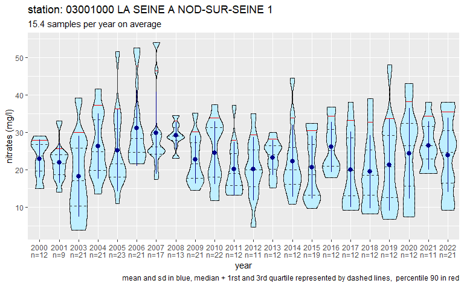

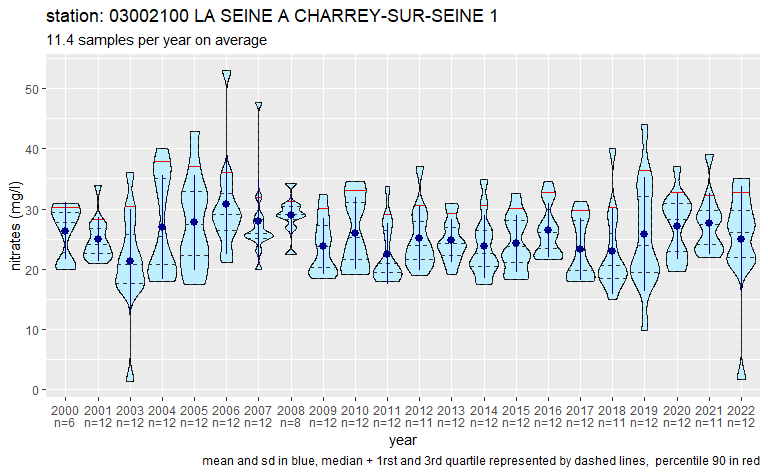

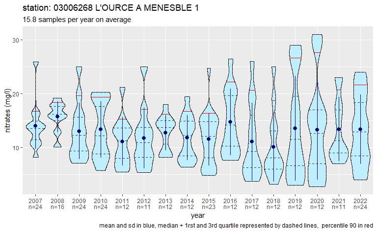

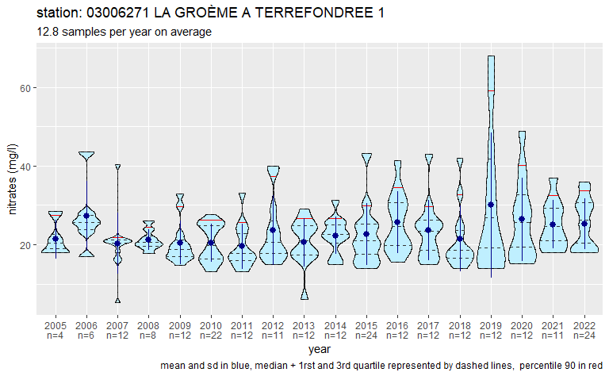

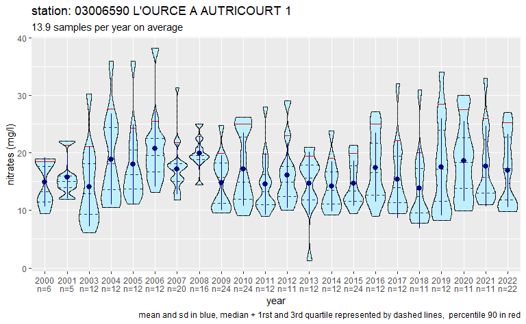

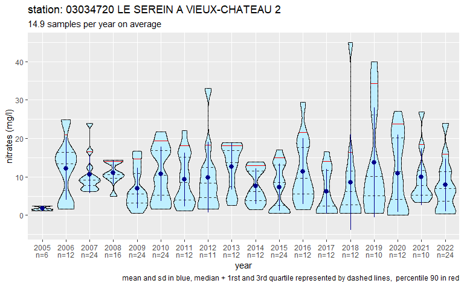

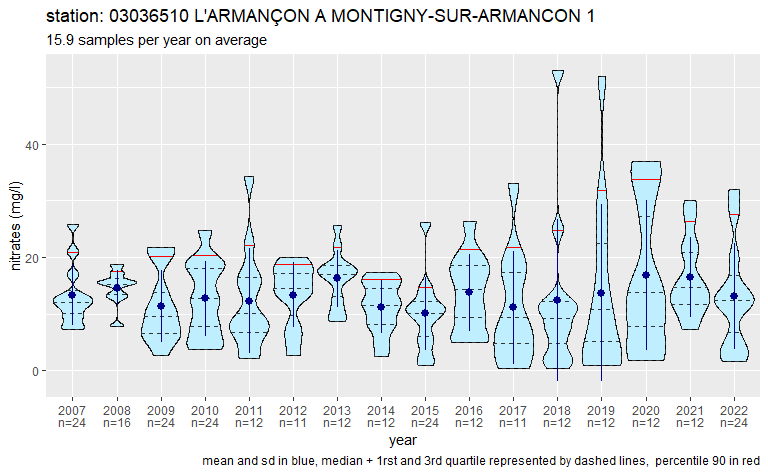

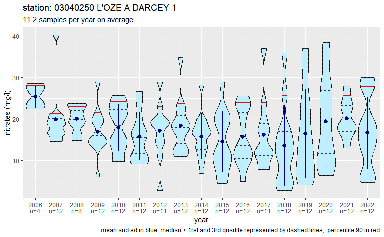

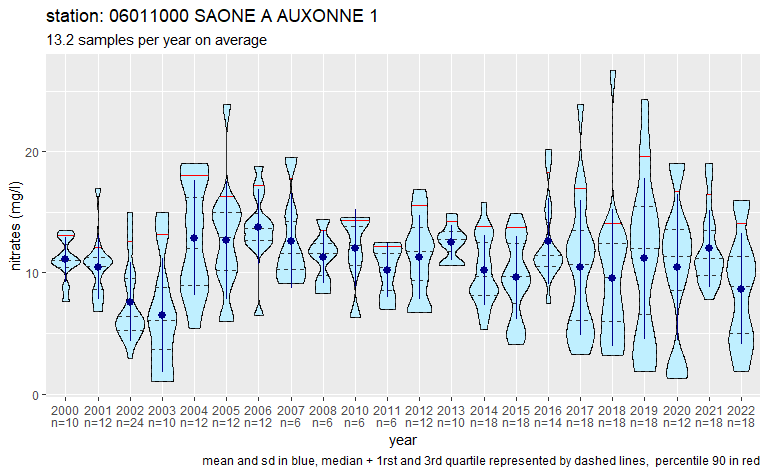

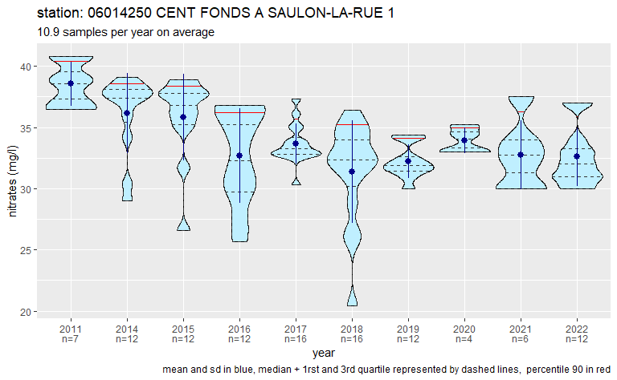

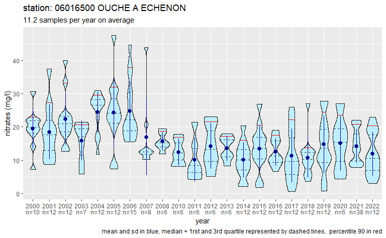

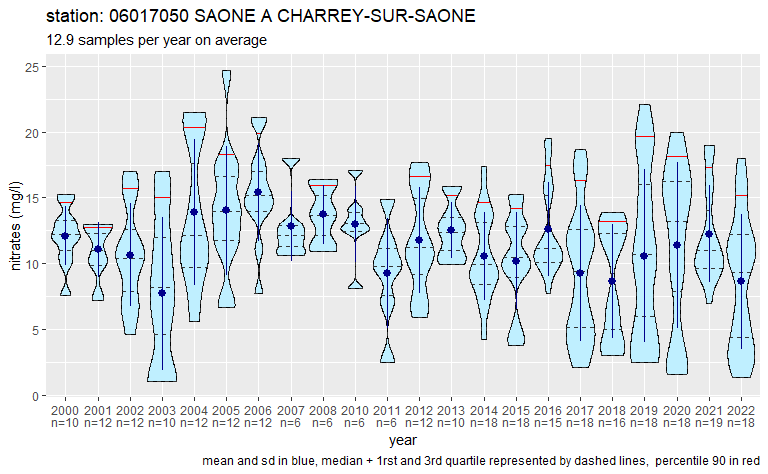

[1 more figures not shown]

```r
lapply(valid_stations$code_station, plot_nitrates)
```